# Chi-Squared Tests Theory

Joseph Bolton

03/05/2021

# Multinomial Distribution

The multinomial distribution is a discrete distribution that is an extension of the binomial distribution. It can be considered to model [the distribution of counts of each face arising from n throws of a k-sided die](https://en.wikipedia.org/wiki/Multinomial_distribution), or *the distribution of outcomes observed over multiple independent trials where the probability of each outcome is the same in each trial*.

The probability mass function of the multinomial distribution is:

$$\begin{array}{lcl}
p(\mathbf{x})
&=&
Pr\Big[X_1=x_1, X_2=x_2, ..., X_k=x_k\Big] \\
\\
k &=& \text{number of possible discrete outcomes (categories)} \\
X_j &=& \text{number of trials which showed outcome } j \\
n &=& \text{total number of trials} \\
\displaystyle\sum_{j=1}^k x_j &=& n \\
\end{array}$$

# Chi-Squared Distribution

The probability density function of a $\chi^2$ distribution with degrees of freedom $k$ is:

$$\begin{array}{lcl}
f(x)
&=&
\displaystyle\frac{x^{\frac{k}{2}-1}e^{-\frac{x}{2}}}{2^{\frac{k}{2}}\Gamma(\frac{k}{2})}
\end{array}$$

The following is a very useful result:

$$\begin{array}{lcl}
\displaystyle\sum_{i=1}^k Z_i^2
&\sim&
\chi^2_k \\
Z_i &\overset{i.i.d.}{\sim}& N(0,1)\\
\end{array}$$

Here is another useful result:

If we have $n$ draws from a multinomial distribution $X\sim\text{multinomial}(p_1,p_2,...,p_k)$ distribution, for example our observed data might look like this:

$$\begin{array}{lcl}
x_1 &=& (0,1,0,0) \\
x_2 &=& (1,0,0,0) \\
x_3 &=& (0,0,0,1) \\
\space &.& \space \\
\space &.& \space \\
x_n &=& (0,0,1,0) \\
\end{array}$$

then the quantity

$$\begin{array}{lcl}
X^2
&=&
\displaystyle\sum_{j=1}^k \frac{(N_j-n \space p_j)^2}{n \space p_j} \\
N_j &=& \text{observed count of trials with outcome } j \\
p_j &=& Pr\Big[X_j=1] \\
&=& \text{probability that a single random draw of } X \text{ will show outcome } j \\
n p_j &=& \text{expected count of trials with outcome } j \text{ under distribution} \hspace{3mm} X\sim\text{multinomial}(p_1,p_2,...,p_k) \\
\end{array}$$

..converges in distribution to a chi-squared distribution with k-1 degrees of freedom. This means that the larger the value of $n$ (the size of our sample), the closer this distribution will resemble a $\chi^2_{k-1}$ distribution.

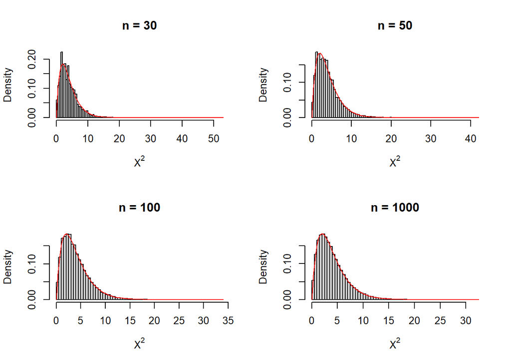

```r
probvec <- c(0.05, 0.4, 0.15, 0.25, 0.15)

par( mfrow = c(2,2) )

for( n in c(30,50,100,1000) ){
  gen_samples <-
      rmultinom(
          n = 1e5L,
          size = n,
          prob = probvec
      )

  ftn_2apply2_cols <-
    function( colvec ){
        sum(
              (colvec - n*probvec)^2 / (n*probvec)
        )
    }
  Xsquared_each_sample <-
    apply( gen_samples,
           MARGIN = 2,
           FUN = ftn_2apply2_cols
          )

  hist(
        Xsquared_each_sample,
        xlab = bquote(X**2),
        main = paste0("n = ", n),
        freq = FALSE,
        breaks = 100
      )
  curve( dchisq(x, df=length(probvec)-1), add=TRUE, col="red" )

}
```

# Chi-Squared Goodness of Fit Test for a Multinomial Distribution

This test is for assessing whether observed data matches a proposed multinomial distribution. The same test can be applied to see whether observed data fit a chosen *continuous* distribution by binning the continuous outcome.

[Seven proofs of the Pearson Chi-squared independence test and its graphical interpretation](https://arxiv.org/pdf/1808.09171.pdf)